# ClimWin Demonstration

#### To be sure the the results of SlidWin were not due to random chance, we run randwin. It should have all the same information from slidwin except the new “repeats =” argument. This allows the user to decide how many times they want to randomise the order of the data and re-run the slidingwin analysis. Due to computational time, we chose 5.

```r
# By running slidingwin on this new randomized dataset we can determine the likelihood of finding our original result by random chance
SlidWin_rand <- randwin(repeats = 5,
                        xvar = list(climate = discharge_data$Discharge_cfs),
                        cdate = discharge_data$Date,
                        bdate = diatoms_discharge$Sampling_date,
                        #baseline = lm(Concentration ~ 1, data = diatoms_discharge),
                        baseline = lme4::lmer(Concentration ~ 1 + (1|Site),
                                              data = diatoms_discharge),
                        cinterval = "day",
                        range = c(30, 0),
                        type = "relative",
                        stat = c("mean", "max"),
                        func = "lin")
```

```
## randomization number 1
```

```
## Initialising, please wait...
```

```
## Linear mixed effects models are run in climwin using maximum likelihood. Baseline model has been changed to use maximum likelihood.
```

```
## fixed-effect model matrix is rank deficient so dropping 1 column / coefficient
```

```
##   |                                                                              |                                                                      |   0%
```

```
## randomization number 2
```

```
## Initialising, please wait...
```

```
## Linear mixed effects models are run in climwin using maximum likelihood. Baseline model has been changed to use maximum likelihood.
```

```
## fixed-effect model matrix is rank deficient so dropping 1 column / coefficient
```

```
##   |                                                                              |                                                                      |   0%
```

```
## randomization number 3
```

```
## Initialising, please wait...
```

```
## Linear mixed effects models are run in climwin using maximum likelihood. Baseline model has been changed to use maximum likelihood.
```

```
## fixed-effect model matrix is rank deficient so dropping 1 column / coefficient
```

```
##   |                                                                              |                                                                      |   0%
```

```
## randomization number 4
```

```
## Initialising, please wait...
```

```
## Linear mixed effects models are run in climwin using maximum likelihood. Baseline model has been changed to use maximum likelihood.
```

```
## fixed-effect model matrix is rank deficient so dropping 1 column / coefficient
```

```
##   |                                                                              |                                                                      |   0%
```

```
## randomization number 5
```

```
## Initialising, please wait...
```

```
## Linear mixed effects models are run in climwin using maximum likelihood. Baseline model has been changed to use maximum likelihood.
```

```
## fixed-effect model matrix is rank deficient so dropping 1 column / coefficient
```

```
##   |                                                                              |                                                                      |   0%
```

```
## randomization number 1
```

```
## Initialising, please wait...
```

```
## Linear mixed effects models are run in climwin using maximum likelihood. Baseline model has been changed to use maximum likelihood.
```

```
## fixed-effect model matrix is rank deficient so dropping 1 column / coefficient
```

```
##   |                                                                              |                                                                      |   0%
```

```
## randomization number 2
```

```
## Initialising, please wait...
```

```
## Linear mixed effects models are run in climwin using maximum likelihood. Baseline model has been changed to use maximum likelihood.
```

```
## fixed-effect model matrix is rank deficient so dropping 1 column / coefficient
```

```
##   |                                                                              |                                                                      |   0%
```

```
## randomization number 3
```

```
## Initialising, please wait...
```

```
## Linear mixed effects models are run in climwin using maximum likelihood. Baseline model has been changed to use maximum likelihood.
```

```
## fixed-effect model matrix is rank deficient so dropping 1 column / coefficient
```

```
##   |                                                                              |                                                                      |   0%
```

```
## randomization number 4
```

```
## Initialising, please wait...
```

```
## Linear mixed effects models are run in climwin using maximum likelihood. Baseline model has been changed to use maximum likelihood.
```

```
## fixed-effect model matrix is rank deficient so dropping 1 column / coefficient
```

```
##   |                                                                              |                                                                      |   0%
```

```
## randomization number 5
```

```
## Initialising, please wait...
```

```
## Linear mixed effects models are run in climwin using maximum likelihood. Baseline model has been changed to use maximum likelihood.
```

```
## fixed-effect model matrix is rank deficient so dropping 1 column / coefficient
```

```
##   |                                                                              |                                                                      |   0%
```

```r
# Naming the model output as an object so we can plug it into plothist
datasetrand = SlidWin_rand[[1]]
SlidWin_rand[[1]]
```

```
##      deltaAICc WindowOpen WindowClose     ModelBeta    Std.Error ModelBetaQ
## 172 -1.1775637         18          18 -2.032483e-04 1.138285e-04         NA
## 211 -0.6638187         20          20 -1.588175e-04 9.713143e-05         NA
## 436  1.0014844         29          29  7.808788e-05 7.782358e-05         NA
## 1    0.0113644          0           0 -1.446921e-04 1.023763e-04         NA
## 465 -1.6437747         29           0  2.362598e-04 1.235774e-04         NA
##     ModelBetaC  ModelInt Function Furthest Closest Statistics     Type K
## 172         NA 1.1226176      lin       30       0       mean relative 0
## 211         NA 1.1020791      lin       30       0       mean relative 0
## 436         NA 0.9797522      lin       30       0       mean relative 0
## 1           NA 1.0827455      lin       30       0       mean relative 0
## 465         NA 0.9079151      lin       30       0       mean relative 0
##       ModWeight sample.size Randomised Repeat WeightDist
## 172 0.003578061           3        yes      1  0.9274194
## 211 0.004692720           3        yes      2  0.9193548
## 436 0.002849832           3        yes      3  0.9415323
## 1   0.003498428           3        yes      4  0.9254032
## 465 0.002969650           3        yes      5  0.9233871
```

```r
pvalue(dataset = SlidWin[[1]]$Dataset, datasetrand = SlidWin_rand[[1]], metric = "C", sample.size = 3)
```

```
## [1] 0.01333871
```

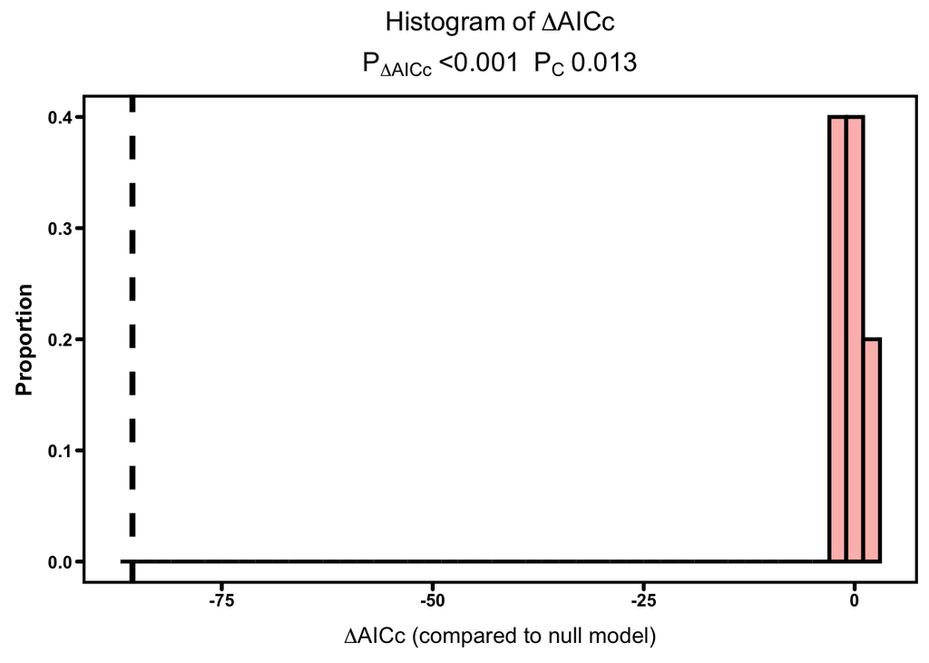

```r
# Sample size is number of years in the dataset
# p < 0.05 original slidingwin result is unlikely to be an issue of overfitting


# This gives a histogram of the ΔAICc
# Values extracted from randwin and a dashed line to show the ΔAICc of the observed result from slidingwin.
plothist(dataset = Output, datasetrand = datasetrand)
```

```r
# As we can see below, the value of ΔAICc from the real data (dashed line) is very different to those values obtained from randomised data, so we can feel confident our results from SlidWin did not occur by chance
```

```r
# We can plot the predictions of our best model over the biological data
# In the singlewin function the values of range now equate to the start and end time of the single best window, rather than the range over which multiple windows will be tested. Look to Output for that top model for this.
SlidWin_single <- singlewin(xvar = list(climate = discharge_data$Discharge_cfs),
                            cdate = discharge_data$Date,
                            bdate = diatoms_discharge$Sampling_date,
                            #baseline = lm(Concentration ~ 1, data = diatoms_discharge),
                            baseline = lme4::lmer(Concentration ~ 1 + (1|Site),
                                                  data = diatoms_discharge),
                            cinterval = "day",
                            range = c(3, 2),
                            type = "relative",
                            stat = c("max"),
                            func = "lin")
```

```
## Linear mixed effects models are run in climwin using maximum likelihood. Baseline model has been changed to use maximum likelihood.
```

```
## fixed-effect model matrix is rank deficient so dropping 1 column / coefficient
```

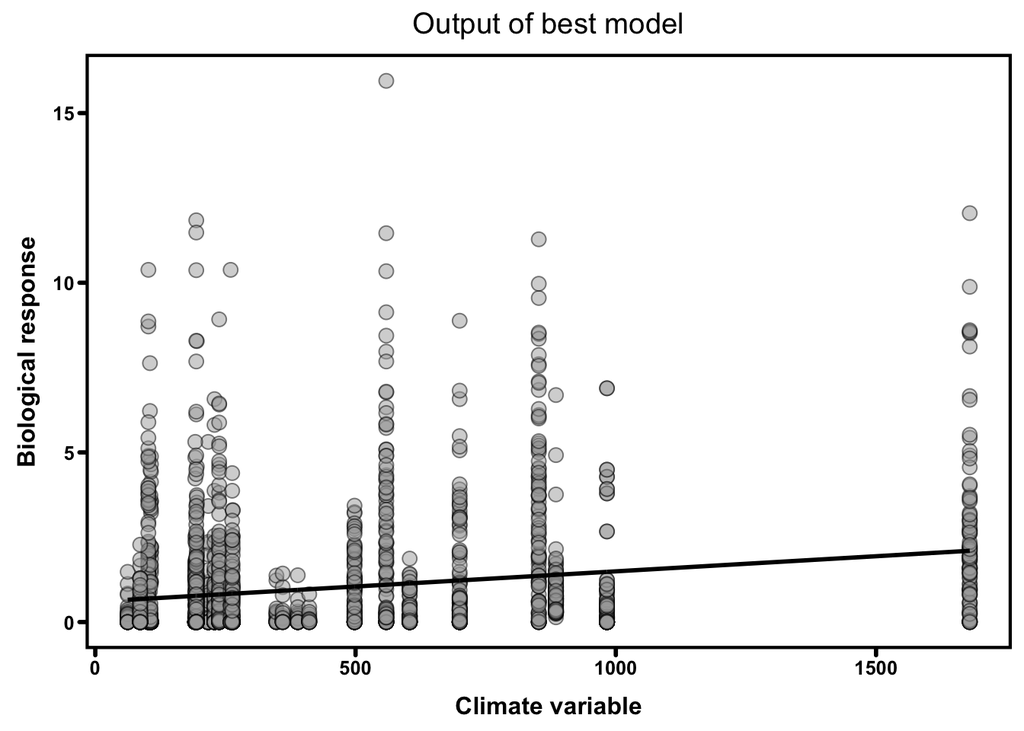

```r
# Examining this plot can help us determine whether it may be more appropriate to test alternative relationships of climate (e.g. quadratic or cubic) by adjusting the parameter func or to identify outliers
plotbest(dataset = Output,
         bestmodel = SlidWin_single$BestModel,
         bestmodeldata = SlidWin_single$BestModelData)
```

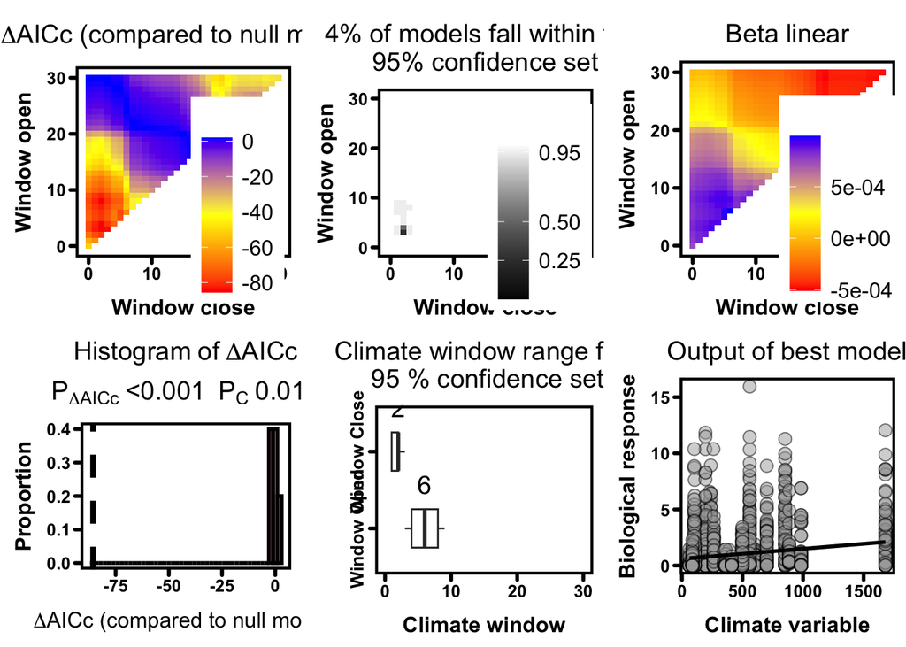

```r
# Plotting everything
plotall(dataset = Output,
        datasetrand = datasetrand,
        bestmodel = SlidWin_single$BestModel,
        bestmodeldata = SlidWin_single$BestModelData)
```